# HW1_Parisi

Jonathan Parisi

```r
#install.packages(c("plyr", "dplyr", "ggplot2"))
library(plyr)
library(dplyr)
library(ggplot2)
```

The Arithmetic mean is equal to $\frac{1}{n} \sum_{i=1}^{n} x_{i}$.

```r
#install.packages("gapminder)
#library(gapminder)
```

**Part A**

```r
gap.delim <- read.delim("http://tiny.cc/gapminder")
dim(gap.delim)
```

```
## [1] 1704    6
```

```r
#gap.table <- read.table("http://tiny.cc/gapminder")
```

The objects are not the same, as read.delim works correctly, returning an object with 1,704 observations and 6 variables, while read.table experiences an error with line 146 and fails to create an object.

To investigate the error, we print line 146 from our object gap.delim, which returns: Bosnia and Herzegovina, 1957, 3.07610^{6}, Europe, 58.45, 1353.989176

With the help of a genius scientist, we surmise that the country name is causing the problem in line 146, and we “realize” we can solve that by specifying the delimiter for the gapminder data. We use the following code:

```r
gap.table = read.table(file='http://tiny.cc/gapminder',sep='\t',header=T)
dim(gap.table)
```

```
## [1] 1698    6
```

However, note that after checking the dimensions, we have 6 fewer observations in this object than in gap.delim, using the read.delim function. There is a problem with Cote D’Ivoire in the read.table generated object, so we revert to using our object gap.delim.

We can test the records involving Cote d’Ivoire by indexing with the grep() function, as seen below.

```r
gap.delim[grep('Cote',gap.delim$country),]
```

```
##           country year      pop continent lifeExp gdpPercap
## 361 Cote d'Ivoire 1952  2977019    Africa  40.477  1388.595
## 362 Cote d'Ivoire 1957  3300000    Africa  42.469  1500.896
## 363 Cote d'Ivoire 1962  3832408    Africa  44.930  1728.869
## 364 Cote d'Ivoire 1967  4744870    Africa  47.350  2052.050
## 365 Cote d'Ivoire 1972  6071696    Africa  49.801  2378.201
## 366 Cote d'Ivoire 1977  7459574    Africa  52.374  2517.737
## 367 Cote d'Ivoire 1982  9025951    Africa  53.983  2602.710
## 368 Cote d'Ivoire 1987 10761098    Africa  54.655  2156.956
## 369 Cote d'Ivoire 1992 12772596    Africa  52.044  1648.074
## 370 Cote d'Ivoire 1997 14625967    Africa  47.991  1786.265
## 371 Cote d'Ivoire 2002 16252726    Africa  46.832  1648.801
## 372 Cote d'Ivoire 2007 18013409    Africa  48.328  1544.750
```

Looks good!

**Part B**

We have several options for exploring our object:

```r
str(gap.delim)
```

```
## 'data.frame':    1704 obs. of  6 variables:
##  $ country  : Factor w/ 142 levels "Afghanistan",..: 1 1 1 1 1 1 1 1 1 1 ...
##  $ year     : int  1952 1957 1962 1967 1972 1977 1982 1987 1992 1997 ...
##  $ pop      : num  8425333 9240934 10267083 11537966 13079460 ...
##  $ continent: Factor w/ 5 levels "Africa","Americas",..: 3 3 3 3 3 3 3 3 3 3 ...
##  $ lifeExp  : num  28.8 30.3 32 34 36.1 ...
##  $ gdpPercap: num  779 821 853 836 740 ...
```

```r
class(gap.delim)
```

```
## [1] "data.frame"
```

Both str() and class() tell us that we are working with a dataframe. Str() shows us there are 6 variables and 1,704 observations. There are several alternative methods. We could use the dim() function to show the number of rows and columns, and head() to show the first few observations, allowing us to see and count the variable names (aka column headers). We could also use the names() function for the variable names, and count their number.

**Part C**

Let’s explore GDP per capita (quantitative) and country (categorical). Forour quantitative variable, we can use summary() to acquire all possible values:

```r
summary(gap.delim$gdpPercap)
```

```
##     Min.  1st Qu.   Median     Mean  3rd Qu.     Max.
##    241.2   1202.0   3532.0   7215.0   9325.0 113500.0
```

This shows that the GDP per capita in our sample ranges from 241.2 to 113,500.Using some other commands, we can discern that the lowest figure is for the Congo in 2002, and the highest for Kuwait in 1957. See below.

```r
gap.delim %>% filter(gdpPercap<245 | gdpPercap>113400)
```

```
##            country year      pop continent lifeExp   gdpPercap
## 1 Congo, Dem. Rep. 2002 55379852    Africa  44.966    241.1659
## 2           Kuwait 1957   212846      Asia  58.033 113523.1329
```

For the categorical variable, we can use the unique() function to find all possible values:

```r
unique(gap.delim$country)
```

```
##   [1] Afghanistan              Albania
##   [3] Algeria                  Angola
##   [5] Argentina                Australia
##   [7] Austria                  Bahrain
##   [9] Bangladesh               Belgium
##  [11] Benin                    Bolivia
##  [13] Bosnia and Herzegovina   Botswana
##  [15] Brazil                   Bulgaria
##  [17] Burkina Faso             Burundi
##  [19] Cambodia                 Cameroon
##  [21] Canada                   Central African Republic
##  [23] Chad                     Chile
##  [25] China                    Colombia
##  [27] Comoros                  Congo, Dem. Rep.
##  [29] Congo, Rep.              Costa Rica
```

[output cut: 57 more lines]

There are 142 countries in the dataset, from Afghanistan to Zimbabwe, in alphabetical order.

For the quantitative variable, GDP per capita, the summary function used above gave us the mean, median and quartiles, from which we can get a sense of the dispersion of the data. Further, we can use summarise() to obtain the standard deviation:

```r
summarise(gap.delim,sd(gdpPercap, na.rm=TRUE))
```

```
##   sd(gdpPercap, na.rm = TRUE)
## 1                    9857.455
```

**Part D**

Task 1

```r
summarise(group_by(gap.delim, continent), max(gdpPercap, na.rm=TRUE), min(gdpPercap, na.rm=TRUE))
```

```
## Source: local data frame [5 x 3]
##
##   continent max(gdpPercap, na.rm = TRUE) min(gdpPercap, na.rm = TRUE)
## 1    Africa                     21951.21                     241.1659
## 2  Americas                     42951.65                    1201.6372
## 3      Asia                    113523.13                     331.0000
## 4    Europe                     49357.19                     973.5332
## 5   Oceania                     34435.37                   10039.5956
```

Task 2

Let’s use a graph, with the nifty facet_wrap() function.

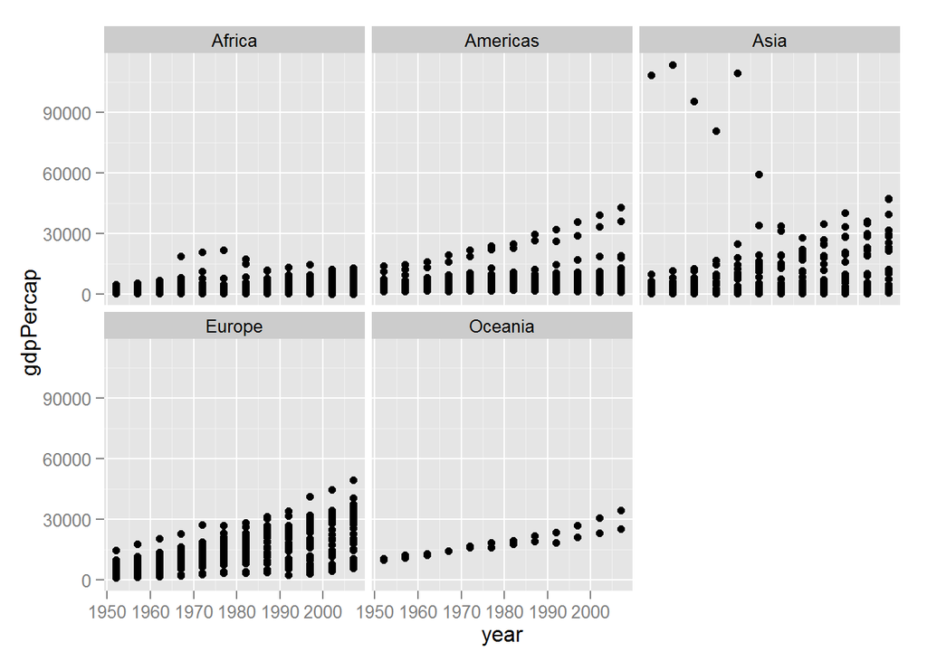

```r
ggplot(gap.delim, aes(x=year, y=gdpPercap)) + geom_point() + facet_wrap(~ continent)
```

Alternatively, to reduce the noise, we could look at just a few different years. This allows us to see the variation a little more clearly:

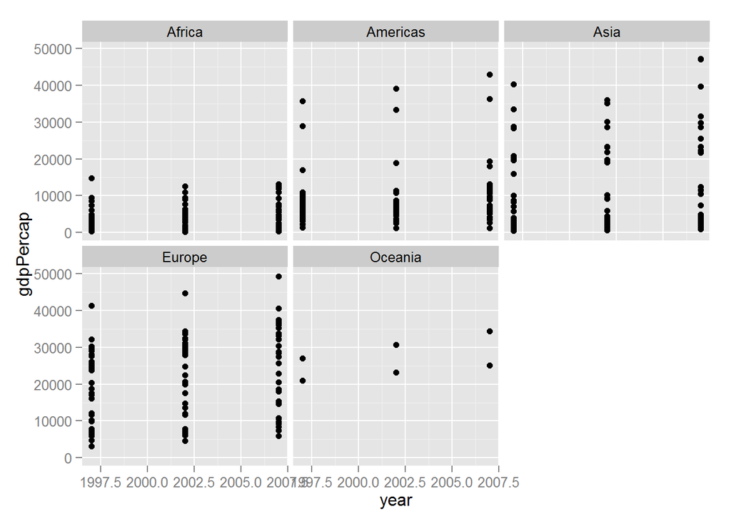

```r
ggplot(filter(gap.delim,year>1993), aes(x=year, y=gdpPercap)) + geom_point() + facet_wrap(~ continent)
```

Task 3

Let’s use group_by() to complete this task, with a 10% trim on each end of the data.

```r
summarise(group_by(gap.delim, year), mean(lifeExp, trim=0.1))
```

```
## Source: local data frame [12 x 2]
##
##    year mean(lifeExp, trim = 0.1)
## 1  1952                  48.57668
## 2  1957                  51.26888
## 3  1962                  53.58075
## 4  1967                  55.86538
## 5  1972                  58.01444
## 6  1977                  60.10206
## 7  1982                  62.11694
## 8  1987                  63.92106
## 9  1992                  65.18519
## 10 1997                  66.01736
## 11 2002                  66.71641
## 12 2007                  68.11489
```

Task 4

For Task 4, we can mirror our earlier graph of GDP per capita, using life expectancy instead. However, because the data points are so widely dispersed in each year, let’s use a line graph instead.

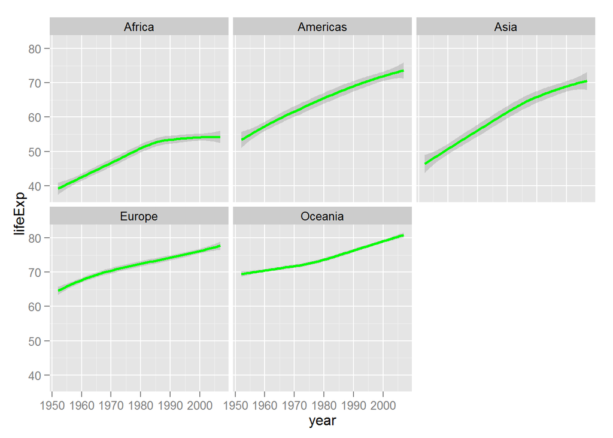

```r
ggplot(gap.delim, aes(x=year, y=lifeExp)) + geom_smooth(lwd=1, color="green") + facet_wrap(~ continent)
```

It looks like life expectancy has risen pretty consistently on most continents over the time period. Unfortunately, the growth in Africa looks to have essentially plateaud since about 1985. We can take a closer look:

```r
gap.delim %>% filter(year>1980, continent=="Africa") %>% group_by(year) %>% summarise(mean(lifeExp, na.rm=TRUE))
```

```
## Source: local data frame [6 x 2]
##
##   year mean(lifeExp, na.rm = TRUE)
## 1 1982                    51.59287
## 2 1987                    53.34479
## 3 1992                    53.62958
## 4 1997                    53.59827
## 5 2002                    53.32523
## 6 2007                    54.80604
```

As expected…

Task 5

```r
summary(gap.delim$lifeExp)
```

```
##    Min. 1st Qu.  Median    Mean 3rd Qu.    Max.
##   23.60   48.20   60.71   59.47   70.85   82.60
```

We see from the above that the 1st quartile of life expectancy worldwide is 48.20, while the median is 60.71. Let’s choose an age of 50 as our threshold beneath which we will consider life expectancy “low”.

```r
gap.delim<-mutate(gap.delim, low.LE = lifeExp <50)
gap.delim[1:15, "low.LE"]
```

```
##  [1]  TRUE  TRUE  TRUE  TRUE  TRUE  TRUE  TRUE  TRUE  TRUE  TRUE  TRUE
## [12]  TRUE FALSE FALSE FALSE
```

```r
summarise(group_by(gap.delim, year, continent),sum(low.LE))
```

```
## Source: local data frame [60 x 3]
## Groups: year
##
##    year continent sum(low.LE)
## 1  1952    Africa          50
## 2  1952  Americas           9
## 3  1952      Asia          22
## 4  1952    Europe           1
## 5  1952   Oceania           0
## 6  1957    Africa          49
## 7  1957  Americas           8
## 8  1957      Asia          18
## 9  1957    Europe           1
## 10 1957   Oceania           0
## ..  ...       ...         ...
```

To test our results, let’s manually list the observations from the Americas in 1957. We should see 8 countries that year with life expectancy below 50 years.

```r
filter(gap.delim, continent=="Americas", year==1957)
```

```
##                country year       pop continent lifeExp gdpPercap low.LE
## 1            Argentina 1957  19610538  Americas  64.399  6856.856  FALSE
## 2              Bolivia 1957   3211738  Americas  41.890  2127.686   TRUE
## 3               Brazil 1957  65551171  Americas  53.285  2487.366  FALSE
## 4               Canada 1957  17010154  Americas  69.960 12489.950  FALSE
## 5                Chile 1957   7048426  Americas  56.074  4315.623  FALSE
## 6             Colombia 1957  14485993  Americas  55.118  2323.806  FALSE
## 7           Costa Rica 1957   1112300  Americas  60.026  2990.011  FALSE
## 8                 Cuba 1957   6640752  Americas  62.325  6092.174  FALSE
## 9   Dominican Republic 1957   2923186  Americas  49.828  1544.403   TRUE
## 10             Ecuador 1957   4058385  Americas  51.356  3780.547  FALSE
## 11         El Salvador 1957   2355805  Americas  48.570  3421.523   TRUE
## 12           Guatemala 1957   3640876  Americas  44.142  2617.156   TRUE
## 13               Haiti 1957   3507701  Americas  40.696  1726.888   TRUE
## 14            Honduras 1957   1770390  Americas  44.665  2220.488   TRUE
## 15             Jamaica 1957   1535090  Americas  62.610  4756.526  FALSE
## 16              Mexico 1957  35015548  Americas  55.190  4131.547  FALSE
## 17           Nicaragua 1957   1358828  Americas  45.432  3457.416   TRUE
## 18              Panama 1957   1063506  Americas  59.201  2961.801  FALSE
## 19            Paraguay 1957   1770902  Americas  63.196  2046.155  FALSE
## 20                Peru 1957   9146100  Americas  46.263  4245.257   TRUE
## 21         Puerto Rico 1957   2260000  Americas  68.540  3907.156  FALSE
## 22 Trinidad and Tobago 1957    764900  Americas  61.800  4100.393  FALSE
## 23       United States 1957 171984000  Americas  69.490 14847.127  FALSE
## 24             Uruguay 1957   2424959  Americas  67.044  6150.773  FALSE
## 25           Venezuela 1957   6702668  Americas  57.907  9802.467  FALSE
```

Voila!

```r
unique(gap.delim$year)
```

```
##  [1] 1952 1957 1962 1967 1972 1977 1982 1987 1992 1997 2002 2007
```

```r
low.LE.byYear=summarise(group_by(gap.delim, year),sum(low.LE))
dim(low.LE.byYear)
```

```
## [1] 12  2
```

```r
head(low.LE.byYear, 20)
```

```
## Source: local data frame [12 x 2]
##
##    year sum(low.LE)
## 1  1952          82
## 2  1957          76
## 3  1962          70
## 4  1967          53
## 5  1972          44
## 6  1977          34
## 7  1982          27
## 8  1987          21
## 9  1992          21
## 10 1997          21
## 11 2002          23
## 12 2007          19
```

```r
sumvar.chart<-low.LE.byYear[,2]
str(sumvar.chart)
```

```
## Classes 'tbl_df' and 'data.frame':   12 obs. of  1 variable:
##  $ sum(low.LE): int  82 76 70 53 44 34 27 21 21 21 ...
```

```r
#ggplot(low.LE.byYear, aes(x=year, y=sumvar.chart) + geom_smooth(lwd=1, color="green") + facet_wrap(~ continent)
```

After multiple tries, apparently I cannot represent my data in graph form no matter what strategy I choose. Moving on…

Task 6

Looking at our earlier graph of GDP per capita, broken down by continent, we see some extreme outliers (high GDP per capita) in the data for Asia. Taking a closer look, we see that all outliers are attributed to the nation of Kuwait. From the 1950’s through the late 1970’s, Kuwait experienced GDP per capita much higher than its neighbors and most of the entire world. The cause of the differential is outside the scope of this exercise.

```r
asia.variation<-gap.delim %>% filter(continent=="Asia", year<1987) %>% arrange(-gdpPercap)
head(asia.variation, 20)
```

```
##         country year       pop continent lifeExp gdpPercap low.LE
## 1        Kuwait 1957    212846      Asia  58.033 113523.13  FALSE
## 2        Kuwait 1972    841934      Asia  67.712 109347.87  FALSE
## 3        Kuwait 1952    160000      Asia  55.565 108382.35  FALSE
## 4        Kuwait 1962    358266      Asia  60.470  95458.11  FALSE
## 5        Kuwait 1967    575003      Asia  64.624  80894.88  FALSE
## 6        Kuwait 1977   1140357      Asia  69.343  59265.48  FALSE
## 7  Saudi Arabia 1977   8128505      Asia  58.690  34167.76  FALSE
## 8  Saudi Arabia 1982  11254672      Asia  63.012  33693.18  FALSE
## 9        Kuwait 1982   1497494      Asia  71.309  31354.04  FALSE
## 10 Saudi Arabia 1972   6472756      Asia  53.886  24837.43  FALSE
## 11        Japan 1982 118454974      Asia  77.110  19384.11  FALSE
## 12      Bahrain 1977    297410      Asia  65.593  19340.10  FALSE
## 13      Bahrain 1982    377967      Asia  69.052  19211.15  FALSE
## 14      Bahrain 1972    230800      Asia  63.300  18268.66  FALSE
## 15 Saudi Arabia 1967   5618198      Asia  49.901  16903.05   TRUE
## 16        Japan 1977 113872473      Asia  75.380  16610.38  FALSE
## 17       Israel 1982   3858421      Asia  74.450  15367.03  FALSE
## 18    Singapore 1982   2651869      Asia  71.760  15169.16  FALSE
## 19      Bahrain 1967    202182      Asia  59.923  14804.67  FALSE
## 20        Japan 1972 107188273      Asia  73.420  14778.79  FALSE
```

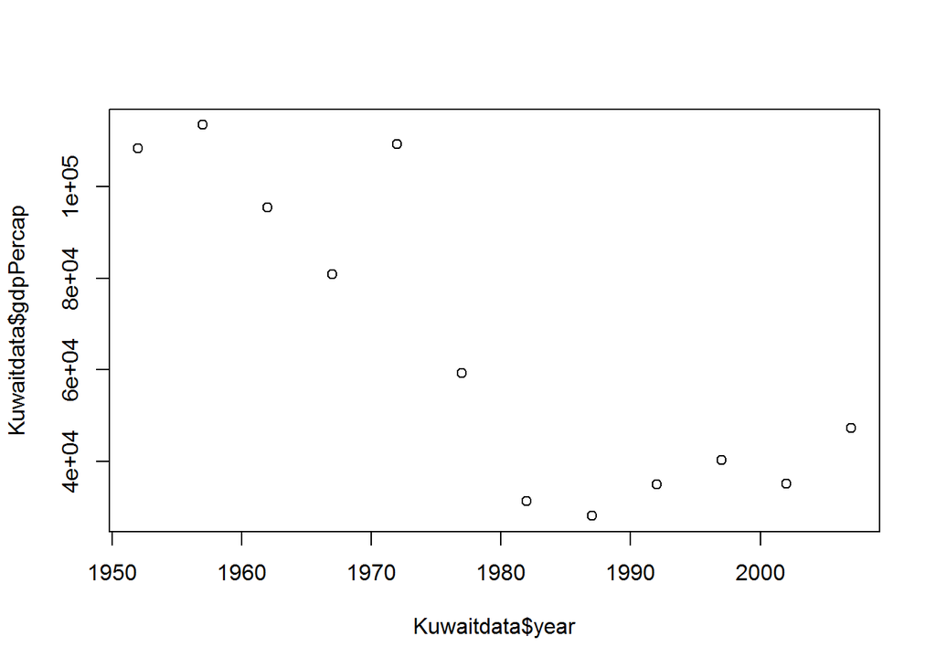

```r
Kuwaitdata<-filter(gap.delim, country=="Kuwait")
plot(x=Kuwaitdata$year, y=Kuwaitdata$gdpPercap)
```

I had some additional ideas for exploration, but needed additional tools that I could not figure out on my own in the required time frame. For example, how to create a new variable for population change over prior year in dataset, and how to create a new variable assigning a “period”, essentially dividing the observations into 15-20 year periods, for use as a facet_wrap variable.